# underscore_rendering_mpl_bug

Jordi

1/28/2022

# Hi.

this is a minimal example to show a minor bug when rendering Rmarkdown w/ matplotlib.  
It is really easy to avoid, simply do not assign stuff to `_`, but it took me a while to realize what was going on.

## Skipable background:

I am a python user, which recently switched to Rmarkdown to use few R libraries while getting most of the job done with python.

To suppress some undesired output in RStudio when using matplotlib (; not working) I tried to assign those lines of code that were generating it to an underscore `_`. As far as I know it is a common practice to store junk variables like iterators in `_`  
(later me: perhaps I was wrong.)

So let's get to the point.

## Imports

```r
knitr::opts_chunk$set(echo = TRUE)
library(reticulate)
data("iris")
```

```python
import matplotlib.pyplot as plt
import seaborn as sns
import pandas as pd
df = r.iris
df.columns = [x.replace('.', '_').lower() for x in df.columns]
df.head()
```

```
##    sepal_length  sepal_width  petal_length  petal_width species
## 0           5.1          3.5           1.4          0.2  setosa
## 1           4.9          3.0           1.4          0.2  setosa
## 2           4.7          3.2           1.3          0.2  setosa
## 3           4.6          3.1           1.5          0.2  setosa
## 4           5.0          3.6           1.4          0.2  setosa
```

## Histogram

`plt.hist` does not give issues when rendering (I guess) because it actually returns an array, so it does not matter whether we assign it to an underscore or not.

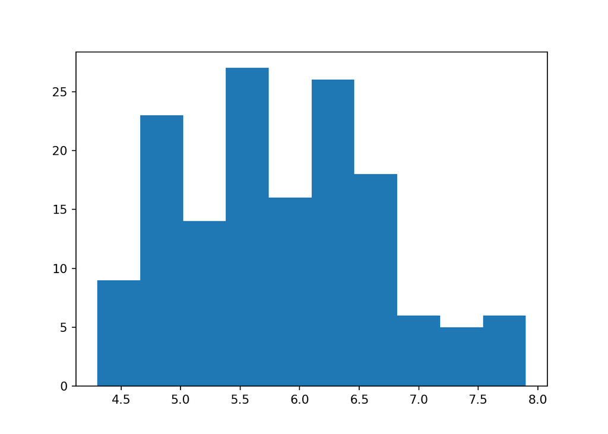

```python
_ = plt.hist(df.sepal_length)
plt.show()
# plt.close() # we do not need close for rendering but for Rstudio, to stop stacking
# alternatively use plt.cla() while using rstudio
```

## Actual bug here (reprex)

I can reproduce it in my environment with this scatterplot

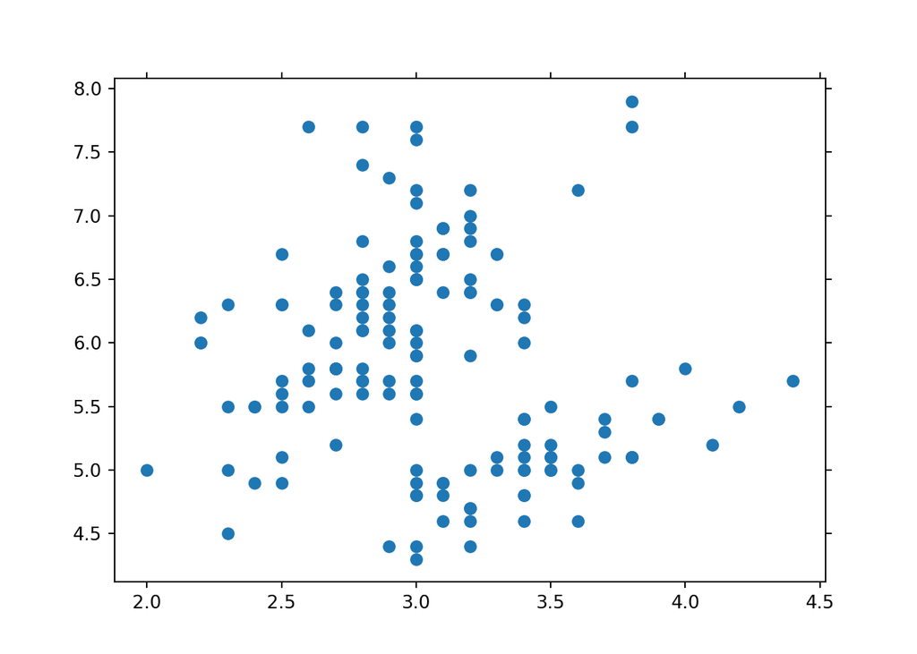

```python
plt.cla()
# plt.scatter( #no issues
# p = plt.scatter( # no issues
_ = plt.scatter( # bug
  df.sepal_width, df.sepal_length
)
plt.show()
# del(_) # it solves the issue
```

```python
plt.close('all')
```

```python
print('the empty figure keeps being printed, above actual output!')
```

[output not shown]

## It also happens when assigning non-figures

check this out!  
(comment out the bug above so you can actually check this one, else everything looks stacked.)

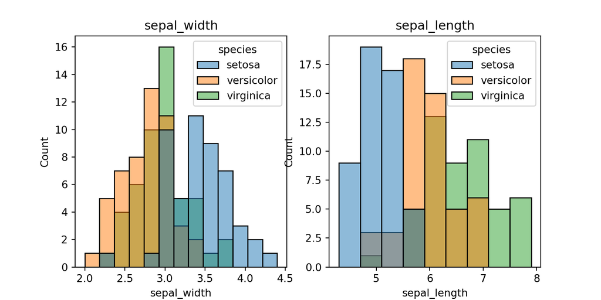

```python
f, ax = plt.subplots(ncols=2, nrows=1, figsize=(8,4))
for i, col in enumerate(['sepal_width', 'sepal_length']):
  # given that the code line below is not being assigned, if there is no figure
  # bug, you will see the output I was trying to suppress, originally
  sns.histplot(data=df, x=col, hue='species', ax=ax[i]);
  # _ = ax[i].set_title(col) # here's the bug
  t = ax[i].set_title(col) # regular behavior

plt.show()
```

```python
plt.close('all')
```

```python
print("If there is a wild figure you won't see this getting printed")
```

[output not shown]

Thanks for maintaining this. You are doing a great job.  
Cheers!